# Momentum Trading Strategy Using Machine Learning

### QuantQuest Hackathon — IIT Mandi Tech Fest (Xpecto 2026)

**Strategy:** A weekly long-only momentum strategy. An ensemble classifier estimates, for each stock, the probability of a positive next-week return. The top-2 ranked stocks are held in equal weight for one week before rebalancing.

| Parameter | Value |
| --- | --- |
| Universe | AAPL, MSFT, GOOGL, AMZN, META, TSLA, JPM, V, JNJ, BRK-B |
| Data | Daily OHLCV via `yfinance` · 2017–2025 |
| Train Period | 2017–2022 |
| Test Period | 2023–2025 (out-of-sample only) |
| Rebalancing | Weekly (Friday close) |
| Transaction Costs | 0.1% on entry + 0.1% on exit, applied only to changed positions |

```python
%matplotlib inline
import yfinance as yf
import pandas as pd
import numpy as np
import matplotlib.pyplot as plt
import matplotlib.gridspec as gridspec
from sklearn.ensemble import RandomForestClassifier, VotingClassifier
from sklearn.linear_model import LogisticRegression
from sklearn.preprocessing import StandardScaler
from sklearn.metrics import roc_auc_score
import warnings
warnings.filterwarnings('ignore')

plt.rcParams.update({'figure.dpi': 130, 'axes.grid': True, 'grid.alpha': 0.3})

TICKERS      = ['AAPL', 'MSFT', 'GOOGL', 'AMZN', 'META',
                 'TSLA', 'JPM', 'V', 'JNJ', 'BRK-B']
START        = '2017-01-01'
END          = '2025-01-01'
TRAIN_END    = '2022-12-31'
TEST_START   = '2023-01-01'
TRANS_COST   = 0.001
FEATURE_COLS = ['ret_1w', 'ret_4w', 'ret_12w', 'ret_26w',
                'price_to_ma20', 'vol_4w', 'vol_ratio', 'rsi']
```

## 1 · Data Acquisition

Daily OHLCV data is sourced via `yfinance` with `auto_adjust=True`, which back-adjusts all prices for corporate actions (splits and dividends), ensuring economically consistent return series.

Weekly prices are obtained by sampling the **last closing price of each Friday** (`resample('W-FRI').last()`), aligning with the weekly holding period of the strategy. Forward-fill is applied across any holiday gaps to avoid spurious missing observations.

```python
raw = yf.download(TICKERS, start=START, end=END, auto_adjust=True, progress=False)

close  = raw['Close'].ffill()
volume = raw['Volume'].ffill()

weekly_close  = close.resample('W-FRI').last().dropna(how='all')
weekly_volume = volume.resample('W-FRI').mean().dropna(how='all')

print(f"Daily rows   : {len(close)}")
print(f"Weekly rows  : {len(weekly_close)}")
print(f"Date range   : {weekly_close.index[0].date()} → {weekly_close.index[-1].date()}")
weekly_close.tail(3)
```

```
Daily rows   : 2012
Weekly rows  : 418
Date range   : 2017-01-06 → 2025-01-03
```

| Ticker Date | AAPL | AMZN | BRK-B | GOOGL | JNJ | JPM | META | MSFT | TSLA | V |
| --- | --- | --- | --- | --- | --- | --- | --- | --- | --- | --- |
| 2024-12-20 | 253.107361 | 224.919998 | 453.200012 | 190.529160 | 139.437759 | 231.629700 | 583.410278 | 432.415894 | 421.059998 | 314.820129 |
| 2024-12-27 | 254.201370 | 223.750000 | 456.510010 | 191.872925 | 139.997543 | 235.110001 | 597.924561 | 426.404083 | 431.660004 | 315.761505 |
| 2025-01-03 | 249.059464 | 219.389999 | 453.279999 | 188.428864 | 139.582504 | 233.686676 | 583.669556 | 417.460602 | 403.839996 | 313.165375 |

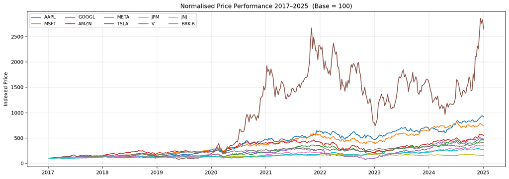

```python
normalised = weekly_close / weekly_close.iloc[0] * 100

fig, ax = plt.subplots(figsize=(14, 5))
for t in TICKERS:
    ax.plot(normalised[t], label=t, lw=1.5)
ax.set_title('Normalised Price Performance 2017–2025  (Base = 100)')
ax.set_ylabel('Indexed Price')
ax.legend(ncol=5, fontsize=9, loc='upper left')
plt.tight_layout()
plt.show()
```

\

## 2 · Feature Engineering

The momentum hypothesis (Jegadeesh & Titman, 1993) posits that stocks exhibiting strong relative performance over an intermediate look-back window continue to outperform over a subsequent holding period. Eight features operationalise this, spanning return momentum across multiple horizons, trend deviation, realised volatility, relative volume, and an oscillator:

| Feature | Definition | Economic Rationale |
| --- | --- | --- |
| `ret_1w` | $\frac{P_t - P_{t-1}}{P_{t-1}}$ | Short-horizon momentum / potential reversal |
| `ret_4w` | $\frac{P_t - P_{t-4}}{P_{t-4}}$ | One-month momentum |
| `ret_12w` | $\frac{P_t - P_{t-12}}{P_{t-12}}$ | Three-month momentum |
| `ret_26w` | $\frac{P_t - P_{t-26}}{P_{t-26}}$ | Canonical Jegadeesh-Titman six-month window |
| `price_to_ma20` | $\frac{P_t}{\bar{P}_{20}} - 1$ | Deviation from 20-week moving average |
| `vol_4w` | $\sigma(r_{t-3:t})$ | Realised 4-week volatility; risk proxy |
| `vol_ratio` | $\frac{V_t}{\bar{V}_{4}}$ | Relative volume; proxy for market conviction |
| `rsi` | $100 - \frac{100}{1 + \frac{\bar{G}_{14}}{\bar{L}_{14}}}$ | RSI(14) — overbought/oversold oscillator |

**Target:** $y_t = \mathbf{1}[r_{t+1} > 0]$, where $r_{t+1}$ is the next-week return. The target is shifted one period forward after feature construction, which is the only mechanism needed to eliminate look-ahead bias — all features at time $t$ use exclusively information available at $t$.

```python
def compute_rsi(series, window=14):
    delta = series.diff()
    gain  = delta.clip(lower=0).rolling(window).mean()
    loss  = (-delta.clip(upper=0)).rolling(window).mean()
    return 100 - (100 / (1 + gain / (loss + 1e-9)))

def build_feature_panel(wclose, wvol):
    frames = []
    for ticker in wclose.columns:
        px, vol = wclose[ticker], wvol[ticker]
        df = pd.DataFrame(index=px.index)
        df['ticker']        = ticker
        df['ret_1w']        = px.pct_change(1)
        df['ret_4w']        = px.pct_change(4)
        df['ret_12w']       = px.pct_change(12)
        df['ret_26w']       = px.pct_change(26)
        df['price_to_ma20'] = px / px.rolling(20).mean() - 1
        df['vol_4w']        = df['ret_1w'].rolling(4).std()
        df['vol_ratio']     = vol / vol.rolling(4).mean()
        df['rsi']           = compute_rsi(px, 14)
        df['next_ret']      = px.pct_change(1).shift(-1)
        df['target']        = (df['next_ret'] > 0).astype(int)
        frames.append(df.dropna())
    return pd.concat(frames)

panel = build_feature_panel(weekly_close, weekly_volume)
print(f"Panel  : {panel.shape}")
print(f"Balance: {panel['target'].value_counts(normalize=True).round(3).to_dict()}")
panel.groupby('ticker')[FEATURE_COLS].mean().round(4)
```

```
Panel  : (3910, 11)
Balance: {1: 0.561, 0: 0.439}
```

| ticker | ret_1w | ret_4w | ret_12w | ret_26w | price_to_ma20 | vol_4w | vol_ratio | rsi |
| --- | --- | --- | --- | --- | --- | --- | --- | --- |
| AAPL | 0.0059 | 0.0238 | 0.0703 | 0.1550 | 0.0494 | 0.0328 | 0.9996 | 60.5972 |
| AMZN | 0.0048 | 0.0193 | 0.0564 | 0.1272 | 0.0385 | 0.0379 | 0.9993 | 58.2665 |
| BRK-B | 0.0029 | 0.0117 | 0.0355 | 0.0749 | 0.0257 | 0.0242 | 1.0021 | 58.7745 |
| GOOGL | 0.0044 | 0.0166 | 0.0475 | 0.1077 | 0.0337 | 0.0355 | 1.0013 | 57.8351 |
| JNJ | 0.0011 | 0.0042 | 0.0144 | 0.0328 | 0.0098 | 0.0224 | 1.0053 | 53.6570 |
| JPM | 0.0038 | 0.0152 | 0.0454 | 0.0959 | 0.0313 | 0.0329 | 1.0002 | 58.0393 |
| META | 0.0049 | 0.0196 | 0.0626 | 0.1475 | 0.0385 | 0.0456 | 1.0020 | 56.2958 |
| MSFT | 0.0055 | 0.0216 | 0.0647 | 0.1480 | 0.0481 | 0.0298 | 1.0011 | 62.4574 |
| TSLA | 0.0112 | 0.0470 | 0.1381 | 0.3457 | 0.0779 | 0.0765 | 1.0023 | 54.1995 |
| V | 0.0038 | 0.0145 | 0.0417 | 0.0891 | 0.0308 | 0.0278 | 1.0017 | 60.0011 |

\

## 3 · Model Architecture

A **soft-voting ensemble** combines two complementary classifiers:

**Random Forest** (`n_estimators=200`, `max_depth=5`, `min_samples_leaf=10`)  
A bagged ensemble of decision trees trained on bootstrap samples with random feature subsets. Depth and leaf-size constraints regularise against overfitting on the limited weekly financial time series. The ensemble aggregates across trees by averaging predicted probabilities.

**Logistic Regression** (`C=0.1`, L2 regularisation)  
A linear baseline that provides a structurally different inductive bias to the RF. Conservative regularisation (`C=0.1`) prevents the model from fitting idiosyncratic noise in the training sample.

**Ensemble output:** $$\hat{p}_t = \frac{1}{2}\left(\hat{p}^{\,RF}_t + \hat{p}^{\,LR}_t\right)$$

Features are standardised before either model receives them: $\tilde{x} = (x - \hat{\mu}) / \hat{\sigma}$, where $\hat{\mu}$ and $\hat{\sigma}$ are estimated exclusively on training data — preventing any leakage of test-period statistics into model fitting.

**Validation:** A hard temporal split at 31 December 2022. The model is trained once on 2017–2022 and evaluated on the 2023–2025 period it has never seen.

```python
train_panel = panel[panel.index <= TRAIN_END]
test_panel  = panel[panel.index >= TEST_START]

predictions_list = []
auc_scores       = {}

for ticker in TICKERS:
    tr = train_panel[train_panel['ticker'] == ticker]
    te = test_panel[test_panel['ticker'] == ticker]

    X_tr, y_tr = tr[FEATURE_COLS].values, tr['target'].values
    X_te       = te[FEATURE_COLS].values

    scaler      = StandardScaler()
    X_tr_sc     = scaler.fit_transform(X_tr)
    X_te_sc     = scaler.transform(X_te)

    rf  = RandomForestClassifier(n_estimators=200, max_depth=5,
                                  min_samples_leaf=10, random_state=42)
    lr  = LogisticRegression(C=0.1, max_iter=1000, random_state=42)
    clf = VotingClassifier([('rf', rf), ('lr', lr)], voting='soft')
    clf.fit(X_tr_sc, y_tr)

    proba = clf.predict_proba(X_te_sc)[:, 1]
    auc_scores[ticker] = roc_auc_score(te['target'].values, proba)

    predictions_list.append(pd.DataFrame({
        'date':     te.index,
        'ticker':   ticker,
        'prob_up':  proba,
        'next_ret': te['next_ret'].values,
        'target':   te['target'].values
    }))

predictions = pd.concat(predictions_list).reset_index(drop=True)

auc_series = pd.Series(auc_scores, name='ROC-AUC').sort_values(ascending=False)
print(f"Mean AUC : {auc_series.mean():.3f}")
print(auc_series.round(3).to_string())
```

```
Mean AUC : 0.495
BRK-B    0.582
JNJ      0.563
AAPL     0.540
META     0.539
JPM      0.538
V        0.477
AMZN     0.472
GOOGL    0.430
TSLA     0.418
MSFT     0.395
```

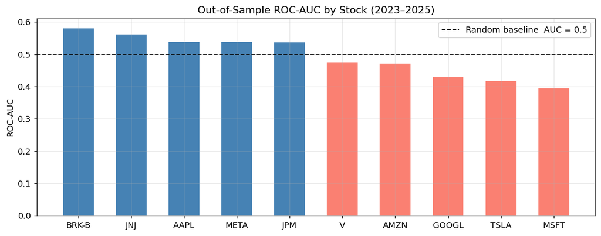

```python
fig, ax = plt.subplots(figsize=(10, 4))
colors  = ['steelblue' if v >= 0.5 else 'salmon' for v in auc_series.values]
ax.bar(auc_series.index, auc_series.values, color=colors, edgecolor='white', width=0.6)
ax.axhline(0.5, color='black', lw=1.2, ls='--', label='Random baseline  AUC = 0.5')
ax.set_title('Out-of-Sample ROC-AUC by Stock (2023–2025)')
ax.set_ylabel('ROC-AUC')
ax.legend()
plt.tight_layout()
plt.show()
```

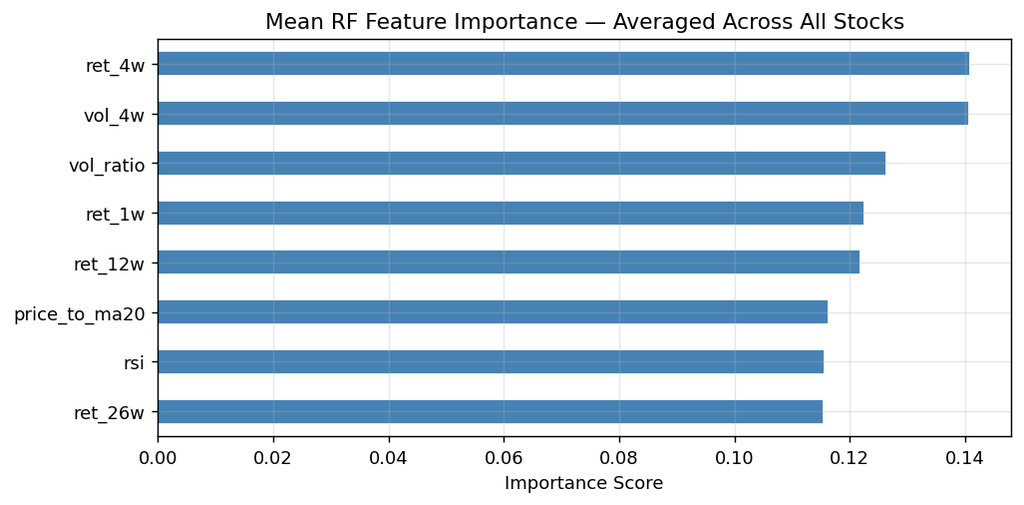

```python
importances = []
for ticker in TICKERS:
    tr = train_panel[train_panel['ticker'] == ticker]
    X_sc = StandardScaler().fit_transform(tr[FEATURE_COLS].values)
    rf_solo = RandomForestClassifier(n_estimators=200, max_depth=5,
                                      min_samples_leaf=10, random_state=42)
    rf_solo.fit(X_sc, tr['target'].values)
    importances.append(rf_solo.feature_importances_)

imp = pd.Series(np.mean(importances, axis=0), index=FEATURE_COLS).sort_values()

fig, ax = plt.subplots(figsize=(8, 4))
imp.plot.barh(ax=ax, color='steelblue', edgecolor='white')
ax.set_title('Mean RF Feature Importance — Averaged Across All Stocks')
ax.set_xlabel('Importance Score')
plt.tight_layout()
plt.show()
```

\

## 4 · Portfolio Construction & Backtest

**Selection rule:** Each Friday, rank all stocks by $\hat{p}_t$ and select: $$\mathcal{S}_t = \underset{i \in \mathcal{U}}{\operatorname{argmax}_2}\;\hat{p}_{i,t}$$

**Gross portfolio return:** $$R^{\text{gross}}_t = \frac{1}{2}\sum_{i \in \mathcal{S}_t} r_{i,t+1}$$

**Transaction cost model:** Costs apply only to positions that actually change between weeks. Let $\mathcal{B}_t = \mathcal{S}_t \setminus \mathcal{S}_{t-1}$ and $\mathcal{E}_t = \mathcal{S}_{t-1} \setminus \mathcal{S}_t$: $$R^{\text{net}}_t = R^{\text{gross}}_t - 0.001 \times 0.5 \times \left(|\mathcal{B}_t| + |\mathcal{E}_t|\right)$$

If the same two stocks are held across consecutive weeks, no cost is incurred — this is more precise than deducting a fixed round-trip cost every period.

```python
prob_pivot = predictions.pivot_table(index='date', columns='ticker', values='prob_up')
ret_pivot  = predictions.pivot_table(index='date', columns='ticker', values='next_ret')

records       = []
prev_holdings = set()

for i, date in enumerate(sorted(prob_pivot.index)):
    row = prob_pivot.loc[date].dropna()
    if len(row) < 2:
        continue

    top2   = set(row.nlargest(2).index)
    sold   = prev_holdings - top2
    bought = top2 - prev_holdings

    tc        = (len(sold) + len(bought)) * 0.5 * TRANS_COST if i > 0 else len(bought) * 0.5 * TRANS_COST
    top2_list = list(top2)
    gross     = ret_pivot.loc[date, top2_list].mean()

    records.append({
        'date':             date,
        'stock_1':          top2_list[0],
        'stock_2':          top2_list[1],
        'weight_1':         0.5,
        'weight_2':         0.5,
        'prob_1':           round(row[top2_list[0]], 4),
        'prob_2':           round(row[top2_list[1]], 4),
        'gross_return':     gross,
        'transaction_cost': tc,
        'net_return':       gross - tc
    })
    prev_holdings = top2

port = pd.DataFrame(records).set_index('date')
print(f"Weeks traded : {len(port)}")
port.head(5)
```

```
Weeks traded : 104
```

| date | stock_1 | stock_2 | weight_1 | weight_2 | prob_1 | prob_2 | gross_return | transaction_cost | net_return |
| --- | --- | --- | --- | --- | --- | --- | --- | --- | --- |
| 2023-01-06 | GOOGL | JPM | 0.5 | 0.5 | 0.5622 | 0.6575 | 0.045742 | 0.001 | 0.044742 |
| 2023-01-13 | AAPL | JPM | 0.5 | 0.5 | 0.6614 | 0.6245 | -0.016186 | 0.001 | -0.017186 |
| 2023-01-20 | AAPL | JPM | 0.5 | 0.5 | 0.7025 | 0.5969 | 0.048626 | 0.000 | 0.048626 |
| 2023-01-27 | BRK-B | AAPL | 0.5 | 0.5 | 0.6672 | 0.6923 | 0.028296 | 0.001 | 0.027296 |
| 2023-02-03 | JNJ | AAPL | 0.5 | 0.5 | 0.6580 | 0.6896 | -0.018021 | 0.001 | -0.019021 |

## 5 · Performance Analysis

All metrics are computed over the **out-of-sample test period (2023–2025)** only. An equal-weight buy-and-hold benchmark across all 10 stocks is included for reference.

```python
def compute_metrics(r, freq=52, label=''):
    r     = r.dropna()
    n     = len(r)
    cum   = (1 + r).prod() - 1
    ann_r = (1 + cum) ** (freq / n) - 1
    ann_v = r.std() * np.sqrt(freq)
    curve = (1 + r).cumprod()
    return pd.Series({
        'Cumulative Return':     cum,
        'Annualized Return':     ann_r,
        'Annualized Volatility': ann_v,
        'Sharpe Ratio':          ann_r / ann_v if ann_v else 0,
        'Max Drawdown':          ((curve - curve.cummax()) / curve.cummax()).min(),
        'Hit Rate':              (r > 0).mean(),
        'Avg Weekly Return':     r.mean()
    }, name=label)

test_wclose = weekly_close[weekly_close.index >= TEST_START]
bmark_r     = test_wclose.pct_change().dropna().mean(axis=1)

m_gross = compute_metrics(port['gross_return'], label='Strategy (Gross)')
m_net   = compute_metrics(port['net_return'],   label='Strategy (Net)')
m_bmark = compute_metrics(bmark_r,              label='Buy & Hold (EW)')

results = pd.concat([m_gross, m_net, m_bmark], axis=1)

pct_rows   = ['Cumulative Return','Annualized Return','Annualized Volatility',
              'Max Drawdown','Hit Rate','Avg Weekly Return']
float_rows = ['Sharpe Ratio']

display_df = results.copy().astype(object)
for col in results.columns:
    for row in pct_rows:
        display_df.loc[row, col] = f"{results.loc[row, col]:.2%}"
    for row in float_rows:
        display_df.loc[row, col] = f"{results.loc[row, col]:.4f}"

display_df
```

|  | Strategy (Gross) | Strategy (Net) | Buy & Hold (EW) |
| --- | --- | --- | --- |
| Cumulative Return | 114.11% | 92.89% | 113.80% |
| Annualized Return | 46.32% | 38.88% | 46.22% |
| Annualized Volatility | 15.29% | 15.32% | 15.82% |
| Sharpe Ratio | 3.0296 | 2.5382 | 2.9206 |
| Max Drawdown | -13.16% | -14.64% | -9.23% |
| Hit Rate | 64.42% | 61.54% | 64.42% |
| Avg Weekly Return | 0.76% | 0.66% | 0.76% |

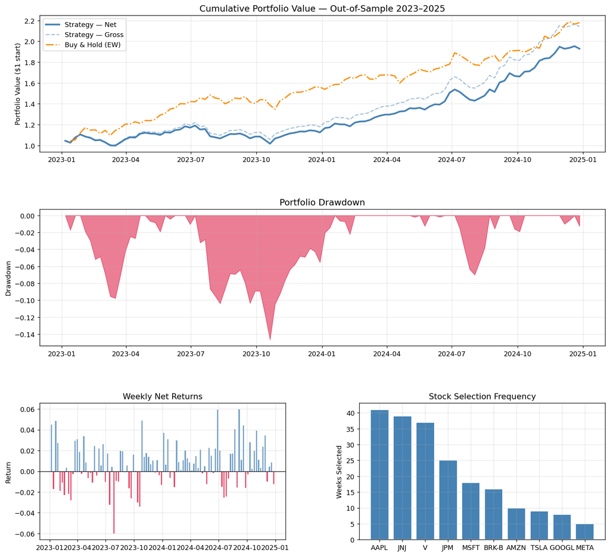

```python
fig = plt.figure(figsize=(15, 14))
gs  = gridspec.GridSpec(3, 2, figure=fig, hspace=0.42, wspace=0.3)

cum_net   = (1 + port['net_return']).cumprod()
cum_gross = (1 + port['gross_return']).cumprod()
cum_bmark = (1 + bmark_r).cumprod().reindex(cum_net.index, method='ffill')
drawdown  = (cum_net - cum_net.cummax()) / cum_net.cummax()

ax0 = fig.add_subplot(gs[0, :])
ax0.plot(cum_net,   label='Strategy — Net',   color='steelblue', lw=2.5)
ax0.plot(cum_gross, label='Strategy — Gross', color='steelblue', lw=1.5, ls='--', alpha=0.5)
ax0.plot(cum_bmark, label='Buy & Hold (EW)',  color='darkorange', lw=1.8, ls='-.')
ax0.set_title('Cumulative Portfolio Value — Out-of-Sample 2023–2025', fontsize=13)
ax0.set_ylabel('Portfolio Value ($1 start)')
ax0.legend(fontsize=10)

ax1 = fig.add_subplot(gs[1, :])
ax1.fill_between(drawdown.index, drawdown.values, 0, color='crimson', alpha=0.55)
ax1.set_title('Portfolio Drawdown', fontsize=13)
ax1.set_ylabel('Drawdown')

ax2 = fig.add_subplot(gs[2, 0])
colors = ['steelblue' if r > 0 else 'crimson' for r in port['net_return']]
ax2.bar(port.index, port['net_return'], color=colors, alpha=0.75, width=4)
ax2.axhline(0, color='black', lw=0.8)
ax2.set_title('Weekly Net Returns', fontsize=12)
ax2.set_ylabel('Return')

ax3 = fig.add_subplot(gs[2, 1])
freq_count = pd.concat([port['stock_1'], port['stock_2']]).value_counts()
ax3.bar(freq_count.index, freq_count.values, color='steelblue', edgecolor='white')
ax3.set_title('Stock Selection Frequency', fontsize=12)
ax3.set_ylabel('Weeks Selected')

plt.savefig('performance_charts.png', dpi=130, bbox_inches='tight')
plt.show()
```

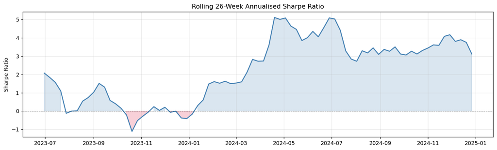

```python
roll = port['net_return'].rolling(26)
rolling_sharpe = (roll.mean() / roll.std()) * np.sqrt(52)

fig, ax = plt.subplots(figsize=(13, 4))
ax.plot(rolling_sharpe, color='steelblue', lw=1.8)
ax.axhline(0, color='black', lw=0.8, ls='--')
ax.fill_between(rolling_sharpe.index, rolling_sharpe,
                where=(rolling_sharpe > 0), alpha=0.2, color='steelblue')
ax.fill_between(rolling_sharpe.index, rolling_sharpe,
                where=(rolling_sharpe < 0), alpha=0.2, color='crimson')
ax.set_title('Rolling 26-Week Annualised Sharpe Ratio')
ax.set_ylabel('Sharpe Ratio')
plt.tight_layout()
plt.show()
```

## 6 · Results Export

```python
export = port.reset_index()
export.columns = [c.replace('_', ' ').title() for c in export.columns]
export.to_csv('weekly_predictions_portfolio.csv', index=False)
print(f"Exported  {len(export)} rows × {len(export.columns)} columns")
export.tail(5)
```

```
Exported  104 rows × 10 columns
```

|  | Date | Stock 1 | Stock 2 | Weight 1 | Weight 2 | Prob 1 | Prob 2 | Gross Return | Transaction Cost | Net Return |
| --- | --- | --- | --- | --- | --- | --- | --- | --- | --- | --- |
| 99 | 2024-11-29 | AAPL | MSFT | 0.5 | 0.5 | 0.6390 | 0.5941 | 0.035353 | 0.001 | 0.034353 |
| 100 | 2024-12-06 | JNJ | AMZN | 0.5 | 0.5 | 0.6916 | 0.6455 | -0.008061 | 0.002 | -0.010061 |
| 101 | 2024-12-13 | JNJ | AAPL | 0.5 | 0.5 | 0.6989 | 0.6779 | 0.005484 | 0.001 | 0.004484 |
| 102 | 2024-12-20 | JNJ | JPM | 0.5 | 0.5 | 0.7120 | 0.6962 | 0.009520 | 0.001 | 0.008520 |
| 103 | 2024-12-27 | JNJ | AAPL | 0.5 | 0.5 | 0.7652 | 0.6278 | -0.011596 | 0.001 | -0.012596 |

\

## 7 · Discussion & Limitations

**Limitations:**  
The 10-stock universe is small; a broader cross-section would improve the signal-to-noise ratio of the ranking step. The model is trained once — a walk-forward retraining scheme (annual or rolling window) would more faithfully represent live deployment. Market impact and bid-ask spread are not modelled; for these large-cap names they are negligible at small notional sizes but would erode returns at scale. Survivorship bias is also present, since all 10 names survived to 2025.

**References:**  
Breiman, L. (2001). Random forests. *Machine Learning*, *45*(1), 5–32. https://doi.org/10.1023/A:1010933404324  
Jegadeesh, N., & Titman, S. (1993). Returns to buying winners and selling losers: Implications for stock market efficiency. *The Journal of Finance*, *48*(1), 65–91. https://doi.org/10.2307/2328882  
Pedregosa, F., et al. (2011). Scikit-learn: Machine learning in Python. *Journal of Machine Learning Research*, *12*, 2825–2830.